# **BCO6008 - ASSESSMENT 3**

Mungunchimeg Batbayar (s4662982), Tsetsegee Amarbayasgalan (s4661830)

2022-11-10

**Loading libraries:**

```r
library(tidyverse)
library(tidymodels)
```

```r
library(skimr)
library(rsample)
library(knitr)
library(ggplot2)
library(dplyr)
library(janitor)
library(forcats)
library(reshape2)
library(heatmaply)
library(gridExtra)
library(themis)
library(stringr)
library(tm)
library(caret)
library(party)
library(e1071)
library(randomForest)
```

**Importing data:**

```r
data <- read_csv("garments_worker_productivity.csv")
```

# **DATA WRANGLING**

Let’s see the data set.

```r
head(data)
```

```
## # A tibble: 6 × 15
##   date   quarter depar…¹ day    team targe…²   smv   wip over_…³ incen…⁴ idle_…⁵
##   <chr>  <chr>   <chr>   <chr> <dbl>   <dbl> <dbl> <dbl>   <dbl>   <dbl>   <dbl>
## 1 1/01/… Quarte… sweing  Thur…     8    0.8  26.2   1108    7080      98       0
## 2 1/01/… Quarte… finish… Thur…     1    0.75  3.94    NA     960       0       0
## 3 1/01/… Quarte… sweing  Thur…    11    0.8  11.4    968    3660      50       0
## 4 1/01/… Quarte… sweing  Thur…    12    0.8  11.4    968    3660      50       0
## 5 1/01/… Quarte… sweing  Thur…     6    0.8  25.9   1170    1920      50       0
## 6 1/01/… Quarte… sweing  Thur…     7    0.8  25.9    984    6720      38       0
## # … with 4 more variables: idle_men <dbl>, no_of_style_change <dbl>,
## #   no_of_workers <dbl>, actual_productivity <dbl>, and abbreviated variable
## #   names ¹department, ²targeted_productivity, ³over_time, ⁴incentive,
## #   ⁵idle_time
```

```r
data%>%skim()
```

Data summary

| Name | Piped data |
| --- | --- |
| Number of rows | 1197 |
| Number of columns | 15 |
| _______________________ |  |
| Column type frequency: |  |
| character | 4 |
| numeric | 11 |
| ________________________ |  |
| Group variables | None |

**Variable type: character**

| skim_variable | n_missing | complete_rate | min | max | empty | n_unique | whitespace |
| --- | --- | --- | --- | --- | --- | --- | --- |
| date | 0 | 1 | 9 | 9 | 0 | 59 | 0 |
| quarter | 0 | 1 | 8 | 8 | 0 | 5 | 0 |
| department | 0 | 1 | 6 | 9 | 0 | 2 | 0 |
| day | 0 | 1 | 6 | 9 | 0 | 6 | 0 |

**Variable type: numeric**

| skim_variable | n_missing | complete_rate | mean | sd | p0 | p25 | p50 | p75 | p100 | hist |
| --- | --- | --- | --- | --- | --- | --- | --- | --- | --- | --- |
| team | 0 | 1.00 | 6.43 | 3.46 | 1.00 | 3.00 | 6.00 | 9.00 | 12.00 | ▇▅▅▆▇ |
| targeted_productivity | 0 | 1.00 | 0.73 | 0.10 | 0.07 | 0.70 | 0.75 | 0.80 | 0.80 | ▁▁▁▁▇ |
| smv | 0 | 1.00 | 15.06 | 10.94 | 2.90 | 3.94 | 15.26 | 24.26 | 54.56 | ▇▅▃▁▁ |
| wip | 506 | 0.58 | 1190.47 | 1837.46 | 7.00 | 774.50 | 1039.00 | 1252.50 | 23122.00 | ▇▁▁▁▁ |
| over_time | 0 | 1.00 | 4567.46 | 3348.82 | 0.00 | 1440.00 | 3960.00 | 6960.00 | 25920.00 | ▇▆▁▁▁ |
| incentive | 0 | 1.00 | 38.21 | 160.18 | 0.00 | 0.00 | 0.00 | 50.00 | 3600.00 | ▇▁▁▁▁ |
| idle_time | 0 | 1.00 | 0.73 | 12.71 | 0.00 | 0.00 | 0.00 | 0.00 | 300.00 | ▇▁▁▁▁ |
| idle_men | 0 | 1.00 | 0.37 | 3.27 | 0.00 | 0.00 | 0.00 | 0.00 | 45.00 | ▇▁▁▁▁ |
| no_of_style_change | 0 | 1.00 | 0.15 | 0.43 | 0.00 | 0.00 | 0.00 | 0.00 | 2.00 | ▇▁▁▁▁ |
| no_of_workers | 0 | 1.00 | 34.61 | 22.20 | 2.00 | 9.00 | 34.00 | 57.00 | 89.00 | ▇▂▂▇▁ |
| actual_productivity | 0 | 1.00 | 0.74 | 0.17 | 0.23 | 0.65 | 0.77 | 0.85 | 1.12 | ▂▂▆▇▂ |

Targeted and Actual productivity variables are the most significant because we will create the outcome variable from the difference between those 2 variables.

```r
summary(data$targeted_productivity)
```

```
##    Min. 1st Qu.  Median    Mean 3rd Qu.    Max.
##  0.0700  0.7000  0.7500  0.7296  0.8000  0.8000
```

```r
summary(data$actual_productivity)
```

```
##    Min. 1st Qu.  Median    Mean 3rd Qu.    Max.
##  0.2337  0.6503  0.7733  0.7351  0.8503  1.1204
```

Data cleaning:

Firstly, cleaning the names of data.

```r
data = data%>%clean_names()
```

Secondly, generating a new variable named variance that is the variance between target and actual productivity.

```r
data1<-data%>% mutate(variance=(actual_productivity-targeted_productivity))
```

Additionally, we created a new characteristic variable based on variance. if the variance is higher than 0 that means the team reached the targeted productivity. On contrary, less then 0 means the team did not reach the target.

```r
data2<-data1%>% mutate(achieved=case_when((actual_productivity-targeted_productivity) > 0 ~ 'yes', T ~ 'no' ))
```

As can seen be, most of them reached the targeted productivity of around 73% and the rest of them did not reach the goal.

```r
data2%>%count(achieved)%>%kable()
```

| achieved | n |
| --- | --- |
| no | 328 |
| yes | 869 |

Let’s peek at brief summary of the data set.

```r
data2%>%summary()
```

```
##      date             quarter           department            day
##  Length:1197        Length:1197        Length:1197        Length:1197
##  Class :character   Class :character   Class :character   Class :character
##  Mode  :character   Mode  :character   Mode  :character   Mode  :character
##
##
##
##
##       team        targeted_productivity      smv             wip
##  Min.   : 1.000   Min.   :0.0700        Min.   : 2.90   Min.   :    7.0
##  1st Qu.: 3.000   1st Qu.:0.7000        1st Qu.: 3.94   1st Qu.:  774.5
##  Median : 6.000   Median :0.7500        Median :15.26   Median : 1039.0
##  Mean   : 6.427   Mean   :0.7296        Mean   :15.06   Mean   : 1190.5
##  3rd Qu.: 9.000   3rd Qu.:0.8000        3rd Qu.:24.26   3rd Qu.: 1252.5
##  Max.   :12.000   Max.   :0.8000        Max.   :54.56   Max.   :23122.0
##                                                         NA's   :506
##    over_time       incentive         idle_time           idle_men
##  Min.   :    0   Min.   :   0.00   Min.   :  0.0000   Min.   : 0.0000
##  1st Qu.: 1440   1st Qu.:   0.00   1st Qu.:  0.0000   1st Qu.: 0.0000
##  Median : 3960   Median :   0.00   Median :  0.0000   Median : 0.0000
##  Mean   : 4567   Mean   :  38.21   Mean   :  0.7302   Mean   : 0.3693
##  3rd Qu.: 6960   3rd Qu.:  50.00   3rd Qu.:  0.0000   3rd Qu.: 0.0000
##  Max.   :25920   Max.   :3600.00   Max.   :300.0000   Max.   :45.0000
##
##  no_of_style_change no_of_workers   actual_productivity    variance
##  Min.   :0.0000     Min.   : 2.00   Min.   :0.2337      Min.   :-0.5619583
##  1st Qu.:0.0000     1st Qu.: 9.00   1st Qu.:0.6503      1st Qu.:-0.0095556
##  Median :0.0000     Median :34.00   Median :0.7733      Median : 0.0005053
##  Mean   :0.1504     Mean   :34.61   Mean   :0.7351      Mean   : 0.0054587
##  3rd Qu.:0.0000     3rd Qu.:57.00   3rd Qu.:0.8503      3rd Qu.: 0.0991111
##  Max.   :2.0000     Max.   :89.00   Max.   :1.1204      Max.   : 0.6443750
##
##    achieved
##  Length:1197
##  Class :character
##  Mode  :character
##
##
##
##
```

We can see that there are 506 missing values in ‘wip’ variable.

```r
data2%>%skim()
```

Data summary

| Name | Piped data |
| --- | --- |
| Number of rows | 1197 |
| Number of columns | 17 |
| _______________________ |  |
| Column type frequency: |  |
| character | 5 |
| numeric | 12 |
| ________________________ |  |
| Group variables | None |

**Variable type: character**

| skim_variable | n_missing | complete_rate | min | max | empty | n_unique | whitespace |
| --- | --- | --- | --- | --- | --- | --- | --- |
| date | 0 | 1 | 9 | 9 | 0 | 59 | 0 |
| quarter | 0 | 1 | 8 | 8 | 0 | 5 | 0 |
| department | 0 | 1 | 6 | 9 | 0 | 2 | 0 |
| day | 0 | 1 | 6 | 9 | 0 | 6 | 0 |
| achieved | 0 | 1 | 2 | 3 | 0 | 2 | 0 |

**Variable type: numeric**

| skim_variable | n_missing | complete_rate | mean | sd | p0 | p25 | p50 | p75 | p100 | hist |
| --- | --- | --- | --- | --- | --- | --- | --- | --- | --- | --- |
| team | 0 | 1.00 | 6.43 | 3.46 | 1.00 | 3.00 | 6.00 | 9.00 | 12.00 | ▇▅▅▆▇ |
| targeted_productivity | 0 | 1.00 | 0.73 | 0.10 | 0.07 | 0.70 | 0.75 | 0.80 | 0.80 | ▁▁▁▁▇ |
| smv | 0 | 1.00 | 15.06 | 10.94 | 2.90 | 3.94 | 15.26 | 24.26 | 54.56 | ▇▅▃▁▁ |
| wip | 506 | 0.58 | 1190.47 | 1837.46 | 7.00 | 774.50 | 1039.00 | 1252.50 | 23122.00 | ▇▁▁▁▁ |
| over_time | 0 | 1.00 | 4567.46 | 3348.82 | 0.00 | 1440.00 | 3960.00 | 6960.00 | 25920.00 | ▇▆▁▁▁ |
| incentive | 0 | 1.00 | 38.21 | 160.18 | 0.00 | 0.00 | 0.00 | 50.00 | 3600.00 | ▇▁▁▁▁ |
| idle_time | 0 | 1.00 | 0.73 | 12.71 | 0.00 | 0.00 | 0.00 | 0.00 | 300.00 | ▇▁▁▁▁ |
| idle_men | 0 | 1.00 | 0.37 | 3.27 | 0.00 | 0.00 | 0.00 | 0.00 | 45.00 | ▇▁▁▁▁ |
| no_of_style_change | 0 | 1.00 | 0.15 | 0.43 | 0.00 | 0.00 | 0.00 | 0.00 | 2.00 | ▇▁▁▁▁ |
| no_of_workers | 0 | 1.00 | 34.61 | 22.20 | 2.00 | 9.00 | 34.00 | 57.00 | 89.00 | ▇▂▂▇▁ |
| actual_productivity | 0 | 1.00 | 0.74 | 0.17 | 0.23 | 0.65 | 0.77 | 0.85 | 1.12 | ▂▂▆▇▂ |
| variance | 0 | 1.00 | 0.01 | 0.16 | -0.56 | -0.01 | 0.00 | 0.10 | 0.64 | ▁▂▇▂▁ |

To improve the predictive analysis, we replaced the missing value with the mean value.

```r
mean_wip<-mean(data2$wip, na.rm=TRUE)
print(mean_wip)
```

```
## [1] 1190.466
```

```r
data2[is.na(data2$wip), "wip"] <- mean_wip
print(data2)
```

```
## # A tibble: 1,197 × 17
##    date  quarter depar…¹ day    team targe…²   smv   wip over_…³ incen…⁴ idle_…⁵
##    <chr> <chr>   <chr>   <chr> <dbl>   <dbl> <dbl> <dbl>   <dbl>   <dbl>   <dbl>
##  1 1/01… Quarte… sweing  Thur…     8    0.8  26.2  1108     7080      98       0
##  2 1/01… Quarte… finish… Thur…     1    0.75  3.94 1190.     960       0       0
##  3 1/01… Quarte… sweing  Thur…    11    0.8  11.4   968     3660      50       0
##  4 1/01… Quarte… sweing  Thur…    12    0.8  11.4   968     3660      50       0
##  5 1/01… Quarte… sweing  Thur…     6    0.8  25.9  1170     1920      50       0
##  6 1/01… Quarte… sweing  Thur…     7    0.8  25.9   984     6720      38       0
##  7 1/01… Quarte… finish… Thur…     2    0.75  3.94 1190.     960       0       0
##  8 1/01… Quarte… sweing  Thur…     3    0.75 28.1   795     6900      45       0
##  9 1/01… Quarte… sweing  Thur…     2    0.75 19.9   733     6000      34       0
## 10 1/01… Quarte… sweing  Thur…     1    0.75 28.1   681     6900      45       0
## # … with 1,187 more rows, 6 more variables: idle_men <dbl>,
## #   no_of_style_change <dbl>, no_of_workers <dbl>, actual_productivity <dbl>,
## #   variance <dbl>, achieved <chr>, and abbreviated variable names ¹department,
## #   ²targeted_productivity, ³over_time, ⁴incentive, ⁵idle_time
```

```r
data2%>%skim()
```

Data summary

| Name | Piped data |
| --- | --- |
| Number of rows | 1197 |
| Number of columns | 17 |
| _______________________ |  |
| Column type frequency: |  |
| character | 5 |
| numeric | 12 |
| ________________________ |  |
| Group variables | None |

**Variable type: character**

| skim_variable | n_missing | complete_rate | min | max | empty | n_unique | whitespace |
| --- | --- | --- | --- | --- | --- | --- | --- |
| date | 0 | 1 | 9 | 9 | 0 | 59 | 0 |
| quarter | 0 | 1 | 8 | 8 | 0 | 5 | 0 |
| department | 0 | 1 | 6 | 9 | 0 | 2 | 0 |
| day | 0 | 1 | 6 | 9 | 0 | 6 | 0 |
| achieved | 0 | 1 | 2 | 3 | 0 | 2 | 0 |

**Variable type: numeric**

| skim_variable | n_missing | complete_rate | mean | sd | p0 | p25 | p50 | p75 | p100 | hist |
| --- | --- | --- | --- | --- | --- | --- | --- | --- | --- | --- |
| team | 0 | 1 | 6.43 | 3.46 | 1.00 | 3.00 | 6.00 | 9.00 | 12.00 | ▇▅▅▆▇ |
| targeted_productivity | 0 | 1 | 0.73 | 0.10 | 0.07 | 0.70 | 0.75 | 0.80 | 0.80 | ▁▁▁▁▇ |
| smv | 0 | 1 | 15.06 | 10.94 | 2.90 | 3.94 | 15.26 | 24.26 | 54.56 | ▇▅▃▁▁ |
| wip | 0 | 1 | 1190.47 | 1395.65 | 7.00 | 970.00 | 1190.47 | 1190.47 | 23122.00 | ▇▁▁▁▁ |
| over_time | 0 | 1 | 4567.46 | 3348.82 | 0.00 | 1440.00 | 3960.00 | 6960.00 | 25920.00 | ▇▆▁▁▁ |
| incentive | 0 | 1 | 38.21 | 160.18 | 0.00 | 0.00 | 0.00 | 50.00 | 3600.00 | ▇▁▁▁▁ |
| idle_time | 0 | 1 | 0.73 | 12.71 | 0.00 | 0.00 | 0.00 | 0.00 | 300.00 | ▇▁▁▁▁ |
| idle_men | 0 | 1 | 0.37 | 3.27 | 0.00 | 0.00 | 0.00 | 0.00 | 45.00 | ▇▁▁▁▁ |
| no_of_style_change | 0 | 1 | 0.15 | 0.43 | 0.00 | 0.00 | 0.00 | 0.00 | 2.00 | ▇▁▁▁▁ |
| no_of_workers | 0 | 1 | 34.61 | 22.20 | 2.00 | 9.00 | 34.00 | 57.00 | 89.00 | ▇▂▂▇▁ |
| actual_productivity | 0 | 1 | 0.74 | 0.17 | 0.23 | 0.65 | 0.77 | 0.85 | 1.12 | ▂▂▆▇▂ |
| variance | 0 | 1 | 0.01 | 0.16 | -0.56 | -0.01 | 0.00 | 0.10 | 0.64 | ▁▂▇▂▁ |

# **DATA VISUALIZATION:**

We made the plots with all variables to seek a relationship with productivity. According to the result, the ‘smv’, ‘wip’, ‘incentive’, ‘idle_men’ and ‘no_of_style_change’ variables were the most positive relationship with the achievement of productivity.

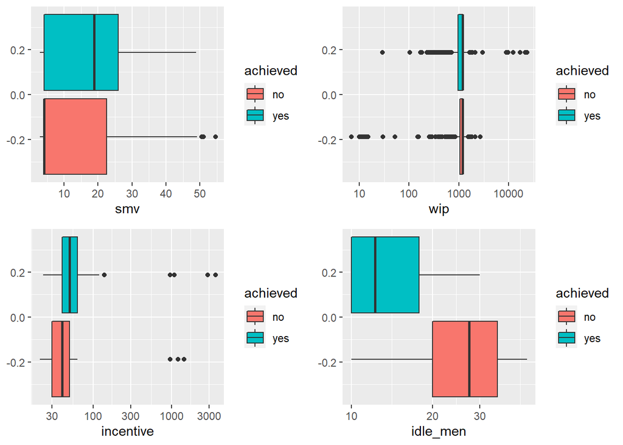

```r
pv1<- data2 %>% ggplot()+geom_boxplot(aes(smv, fill = achieved))
pv2<- data2 %>% ggplot()+geom_boxplot(aes(wip, fill = achieved))+scale_x_log10()
pv3<- data2 %>% ggplot()+geom_boxplot(aes(incentive, fill = achieved)) +scale_x_log10()
pv4<- data2 %>% ggplot()+geom_boxplot(aes(idle_men, fill = achieved)) +scale_x_log10()


grid.arrange(pv1,pv2,pv3,pv4, nrow=2)
```

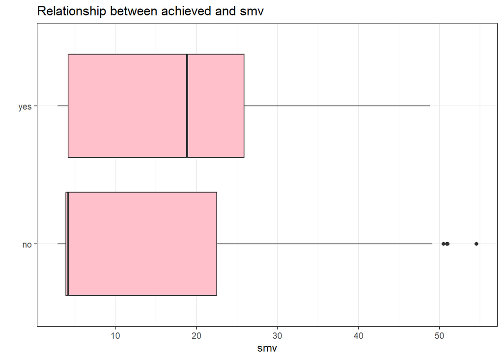

```r
data2 %>%
  ggplot(aes(achieved, smv)) +
  geom_boxplot( fill = 'pink') +
  theme_bw() +
  coord_flip() +
  labs(x = '', y = "smv",
       title = 'Relationship between achieved and smv')
```

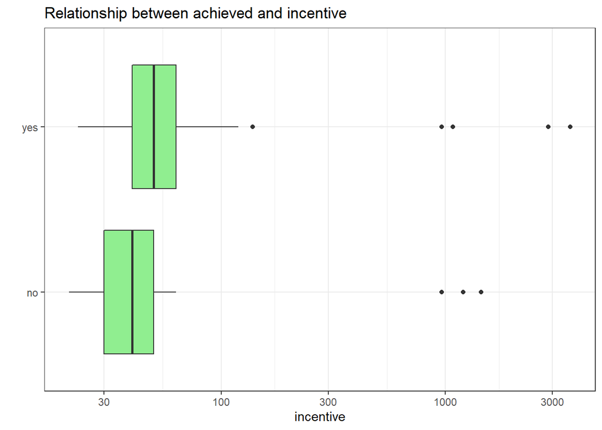

```r
data2 %>%
  ggplot(aes(achieved, incentive)) +
  geom_boxplot( fill = 'light green') +
  scale_y_log10()+
  theme_bw() +
  coord_flip() +
  labs(x = '', y = "incentive",
       title = 'Relationship between achieved and incentive')
```

SMV:

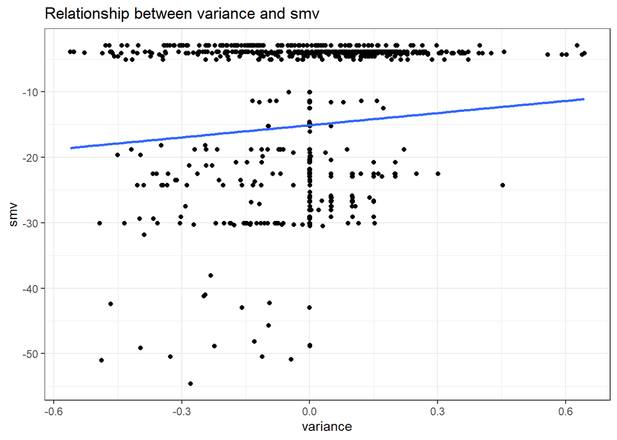

```r
data2 %>%
  ggplot(aes(variance, -smv)) +
  geom_point() +
  geom_smooth(method = lm, se = FALSE) +
  theme_bw() +
  labs(x = 'variance', y = "smv",
       title = 'Relationship between variance and smv')
```

WIP:

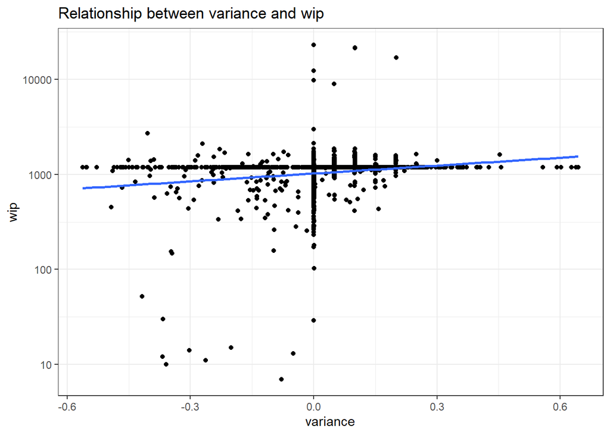

```r
data2 %>%
  ggplot(aes(variance, wip)) +
  geom_point() +
  scale_y_log10()+
  geom_smooth(method = lm, se = FALSE) +
  theme_bw() +
  labs(x = 'variance', y = "wip",
       title = 'Relationship between variance and wip')
```

OVER_TIME:

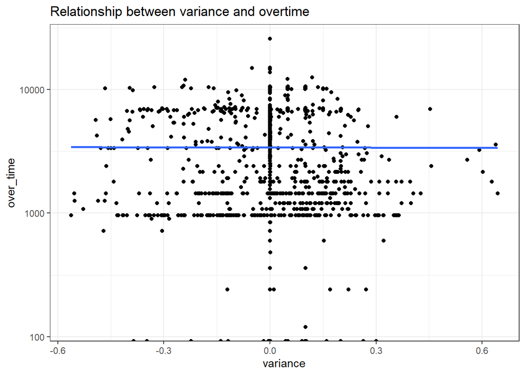

```r
data2 %>%
  ggplot(aes(variance, over_time)) +
  geom_point() +
  scale_y_log10()+
  geom_smooth(method = lm, se = FALSE) +
  theme_bw() +
  labs(x = 'variance', y = "over_time",
       title = 'Relationship between variance and overtime')
```

INCENTIVE:

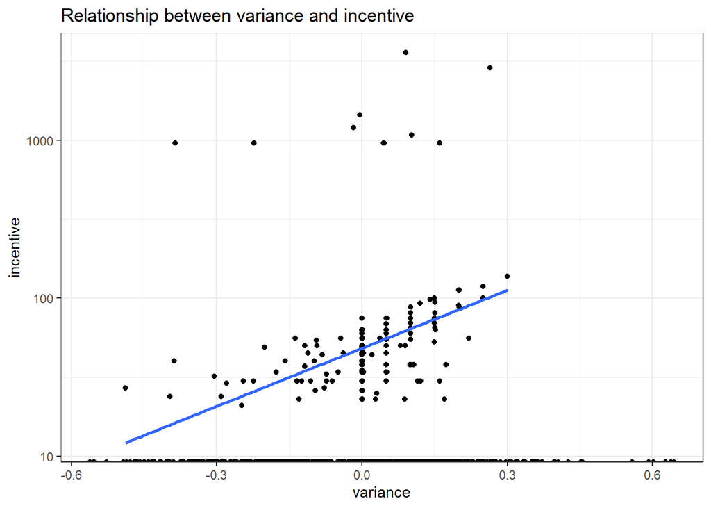

```r
data2 %>%
  ggplot(aes(variance, incentive)) +
  geom_point() +
  scale_y_log10()+
  geom_smooth(method = lm, se = FALSE) +
  theme_bw() +
  labs(x = 'variance', y = "incentive",
       title = 'Relationship between variance and incentive')
```

IDLE_TIME:

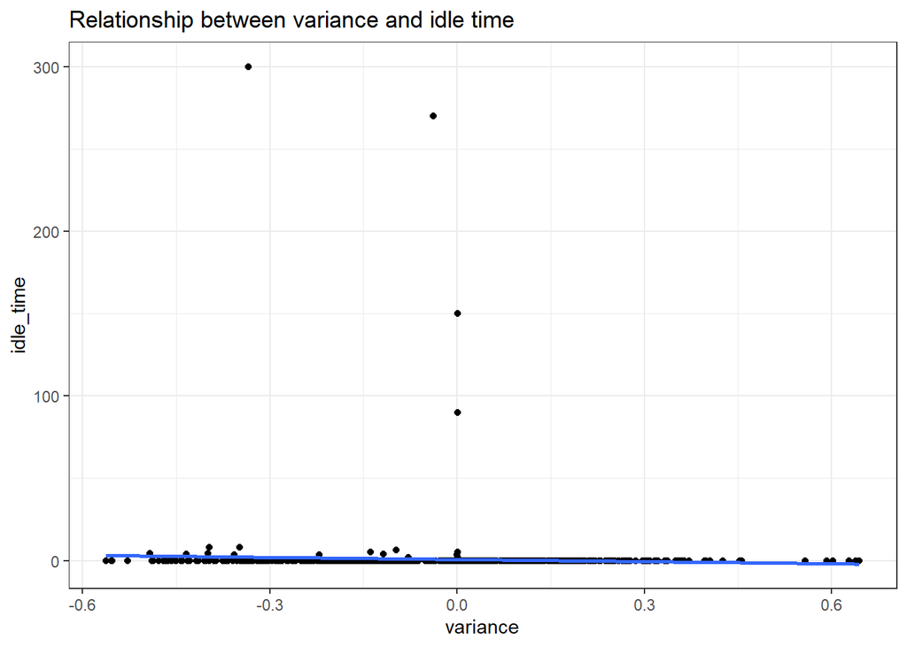

```r
data2 %>%
  ggplot(aes(variance, idle_time)) +
  geom_point() +
  geom_smooth(method = lm, se = FALSE) +
  theme_bw() +
  labs(x = 'variance', y = "idle_time",
       title = 'Relationship between variance and idle time')
```

IDLE_MEN:

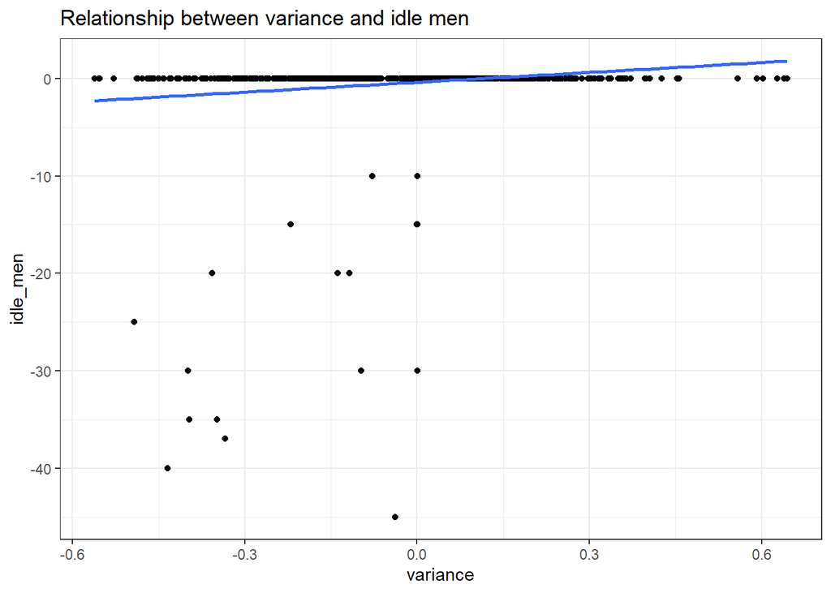

```r
data2 %>%
  ggplot(aes(variance, -idle_men)) +
  geom_point() +
  geom_smooth(method = lm, se = FALSE) +
  theme_bw() +
  labs(x = 'variance', y = "idle_men",
       title = 'Relationship between variance and idle men')
```

NO_OF_STYLE_CHANGE:

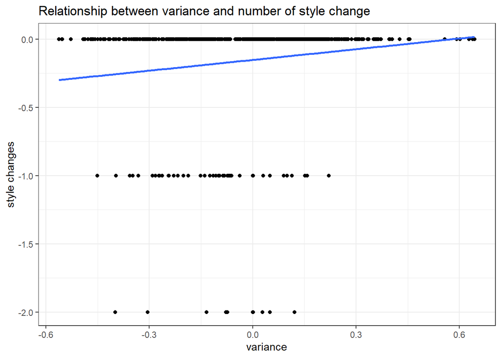

```r
data2 %>%
  ggplot(aes(variance, -no_of_style_change)) +
  geom_point() +
  geom_smooth(method = lm, se = FALSE) +
  theme_bw() +
  labs(x = 'variance', y = "style changes",
       title = 'Relationship between variance and number of style change')
```

```r
data2%>% group_by(achieved)%>%count(no_of_style_change)%>%ungroup()
```

```
## # A tibble: 6 × 3
##   achieved no_of_style_change     n
##   <chr>                 <dbl> <int>
## 1 no                        0   286
## 2 no                        1    35
## 3 no                        2     7
## 4 yes                       0   764
## 5 yes                       1    79
## 6 yes                       2    26
```

NO_OF_WORKERS:

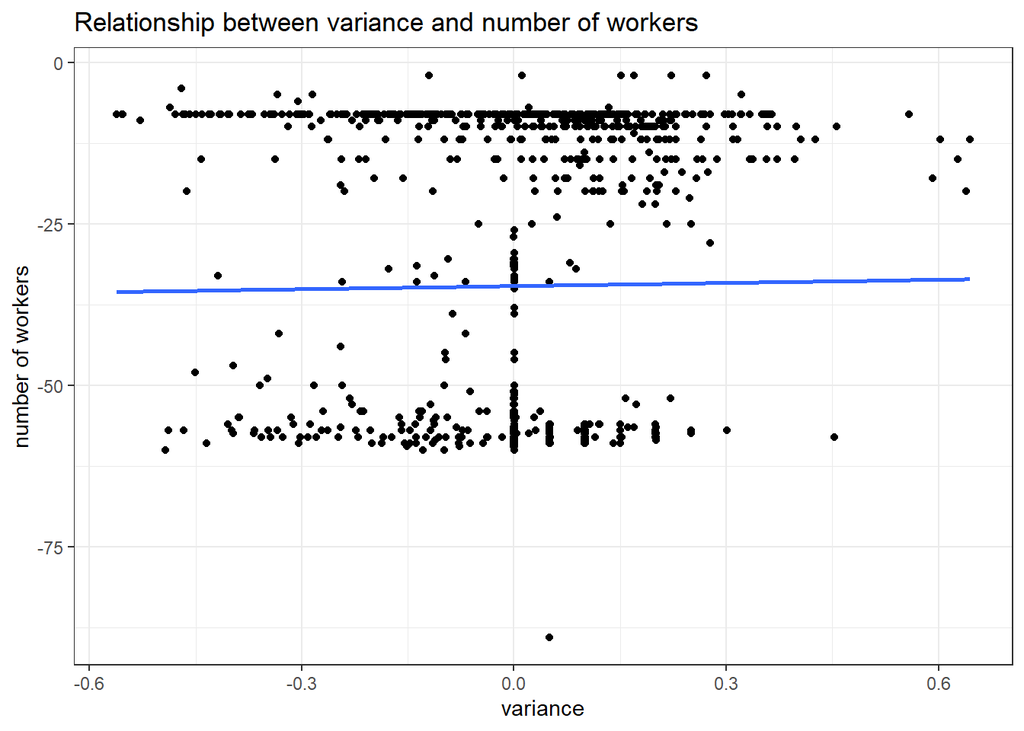

```r
data2 %>%
  ggplot(aes(variance, -no_of_workers)) +
  geom_point() +
  geom_smooth(method = lm, se = FALSE) +
  theme_bw() +
  labs(x = 'variance', y = "number of workers",
       title = 'Relationship between variance and number of workers')
```

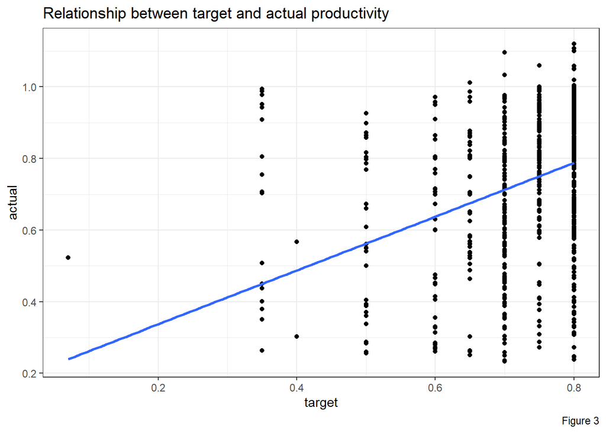

```r
data2 %>%
  ggplot(aes(targeted_productivity, actual_productivity)) +
  geom_point() +
  geom_smooth(method = lm, se = FALSE) +
  theme_bw() +
  labs(x = 'target', y = "actual",
       title = 'Relationship between target and actual productivity', caption = 'Figure 3')
```

Let’s check the distribution of the variance

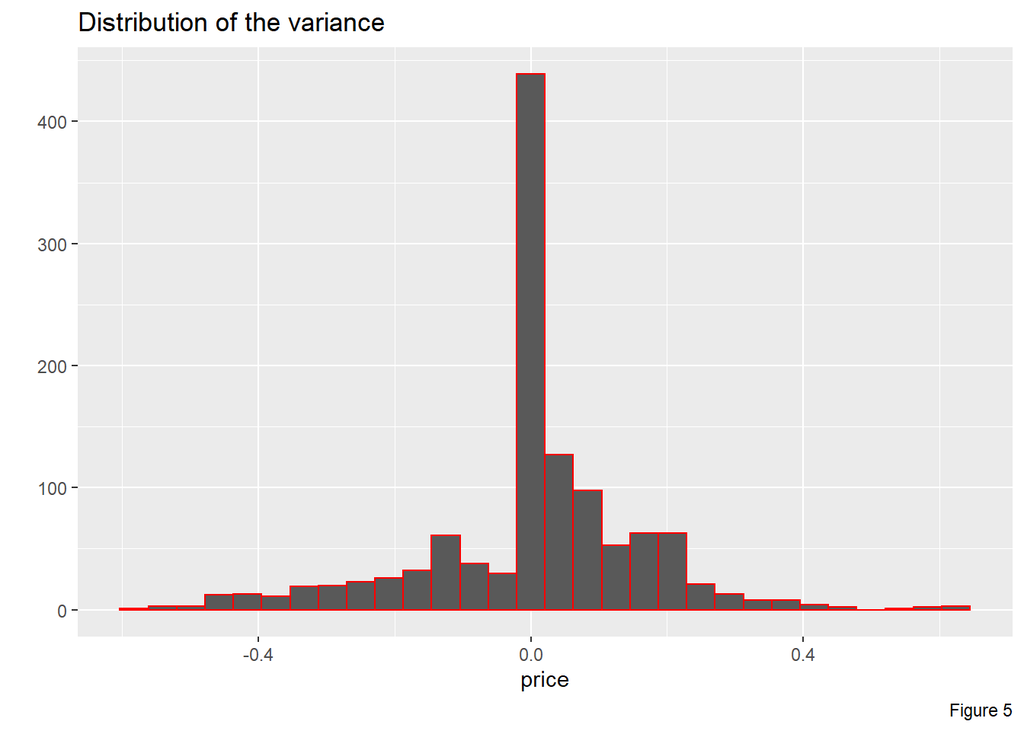

```r
data2 %>%
  ggplot(aes(variance)) +
  geom_histogram(bins = 30, color = "red") +
  labs(x = "price", y = " ",
       title = "Distribution of the variance", caption = "Figure 5")
```

Some unnecessary variables named date, quarter, day, the number of teams, department and variance were removed from data that won’t be used in the data modelling.

```r
dat <- data2%>%
  select(-date, -quarter, -day, -team, -department, -variance)%>%
  mutate_if(is.character, as.factor)

glimpse(dat)
```

```
## Rows: 1,197
## Columns: 11
## $ targeted_productivity <dbl> 0.80, 0.75, 0.80, 0.80, 0.80, 0.80, 0.75, 0.75, …
## $ smv                   <dbl> 26.16, 3.94, 11.41, 11.41, 25.90, 25.90, 3.94, 2…
## $ wip                   <dbl> 1108.000, 1190.466, 968.000, 968.000, 1170.000, …
## $ over_time             <dbl> 7080, 960, 3660, 3660, 1920, 6720, 960, 6900, 60…
## $ incentive             <dbl> 98, 0, 50, 50, 50, 38, 0, 45, 34, 45, 44, 45, 50…
## $ idle_time             <dbl> 0, 0, 0, 0, 0, 0, 0, 0, 0, 0, 0, 0, 0, 0, 0, 0, …
## $ idle_men              <dbl> 0, 0, 0, 0, 0, 0, 0, 0, 0, 0, 0, 0, 0, 0, 0, 0, …
## $ no_of_style_change    <dbl> 0, 0, 0, 0, 0, 0, 0, 0, 0, 0, 0, 0, 0, 0, 0, 0, …
## $ no_of_workers         <dbl> 59.0, 8.0, 30.5, 30.5, 56.0, 56.0, 8.0, 57.5, 55…
## $ actual_productivity   <dbl> 0.9407254, 0.8865000, 0.8005705, 0.8005705, 0.80…
## $ achieved              <fct> yes, yes, yes, yes, yes, yes, yes, yes, yes, yes…
```

# **DATA MODELLING**

## **Model 1: Prediction modelling using all predictors:**

```r
bayesAcc = c();
randomAcc = c();
```

```r
for(i in 1:100){
  ind = sample(2, nrow(dat),replace = T, prob = c(0.75,0.25))
  table(ind)
  train_data = dat[ind == 1, ]
  test_data = dat[ind == 2, ]
  print(dim(train_data))
  print(dim(test_data))

  # Naive Bayes  model using train data
  dat_bayes = naiveBayes(train_data$achieved ~., data = train_data)
  print("Results of Naive Bayes classifier")
  # Evaluate the model using test data
  testPrediction = predict(dat_bayes, test_data)
  conf = table(test_data$achieved , testPrediction)
  cm = confusionMatrix(test_data$achieved , testPrediction)
  bayesAcc[i] = mean(cm$byClass[])
  print(bayesAcc[i])

  # Random Forest model using the train data
  dat_random = randomForest(train_data$achieved  ~., data = train_data)
  # Evaluate the model using test data
  testPrediction = predict(dat_random, test_data)
  conf = table(test_data$achieved , testPrediction)
  cm = confusionMatrix(test_data$achieved , testPrediction)
  print("Results of Random Forest  classifier")
  randomAcc[i] = mean(cm$byClass[])
  print(randomAcc[i])
}
```

```
## [1] 889  11
## [1] 308  11
## [1] "Results of Naive Bayes classifier"
## [1] 0.6333203
## [1] "Results of Random Forest  classifier"
## [1] 0.790789
## [1] 903  11
## [1] 294  11
## [1] "Results of Naive Bayes classifier"
## [1] 0.5940824
## [1] "Results of Random Forest  classifier"
## [1] 0.7684022
## [1] 924  11
## [1] 273  11
## [1] "Results of Naive Bayes classifier"
```

[output cut: 585 more lines]

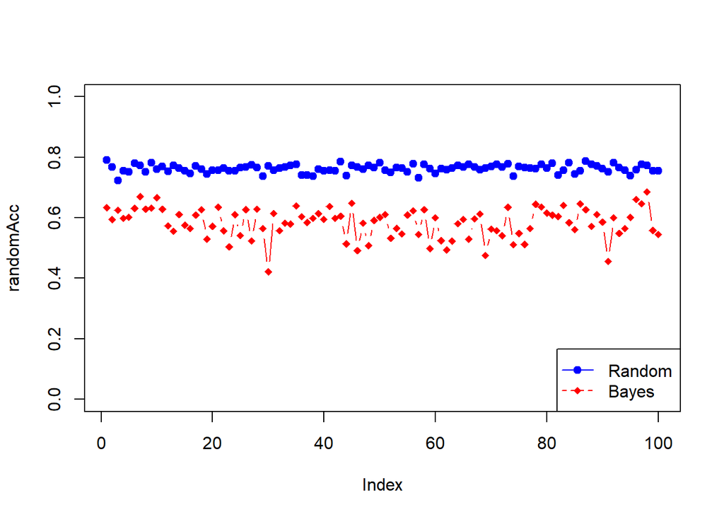

```r
plot(randomAcc, type="b",ylim=c(0,1),col="blue",pch=19)
lines(bayesAcc,type="b",col="red",pch=18)


legend("bottomright",legend=c("Random","Bayes"),col=c("blue","red"),pch=c(19,18),lty=1:2)
```

```r
ttest = t.test(randomAcc, bayesAcc)
print(ttest)
```

```
##
##  Welch Two Sample t-test
##
## data:  randomAcc and bayesAcc
## t = 34.835, df = 112.82, p-value < 2.2e-16
## alternative hypothesis: true difference in means is not equal to 0
## 95 percent confidence interval:
##  0.1681237 0.1884009
## sample estimates:
## mean of x mean of y
## 0.7624585 0.5841962
```

```r
print(mean(bayesAcc))
```

```
## [1] 0.5841962
```

```r
print(mean(randomAcc))
```

```
## [1] 0.7624585
```

## **Model 2: Prediction model using smv + wip + incentive + idle_men + no_of_style_change:**

```r
bayesAcc1= c();
randomAcc1 = c();
```

```r
for(i in 1:100){
  ind = sample(2, nrow(dat),replace = T, prob = c(0.75,0.25))
  table(ind)
  train_data = dat[ind == 1, ]
  test_data = dat[ind == 2, ]
  print(dim(train_data))
  print(dim(test_data))

  # Naive Bayes  model using train data
  dat_bayes = naiveBayes(train_data$achieved ~  smv + wip + incentive + idle_men +   no_of_style_change, data = train_data)
  print("Results of Naive Bayes classifier")
  # Evaluate the model using test data
  testPrediction = predict(dat_bayes, test_data)
  conf = table(test_data$achieved , testPrediction)
  cm = confusionMatrix(test_data$achieved , testPrediction)
  bayesAcc1[i] = mean(cm$byClass[])
  print(bayesAcc1[i])

  # Random Forest model using the train data
  dat_random = randomForest(train_data$achieved  ~ smv + wip + incentive + idle_men + no_of_style_change, data = train_data)
  # Evaluate the model using test data
  testPrediction = predict(dat_random, test_data)
  conf = table(test_data$achieved , testPrediction)
  cm = confusionMatrix(test_data$achieved , testPrediction)
  print("Results of Random Forest  classifier")
  randomAcc1[i] = mean(cm$byClass[])
  print(randomAcc1[i])
}
```

```
## [1] 881  11
## [1] 316  11
## [1] "Results of Naive Bayes classifier"
## [1] 0.3405403
## [1] "Results of Random Forest  classifier"
## [1] 0.5530959
## [1] 883  11
## [1] 314  11
## [1] "Results of Naive Bayes classifier"
## [1] 0.5321384
## [1] "Results of Random Forest  classifier"
## [1] 0.5772288
## [1] 892  11
## [1] 305  11
## [1] "Results of Naive Bayes classifier"
```

[output cut: 585 more lines]

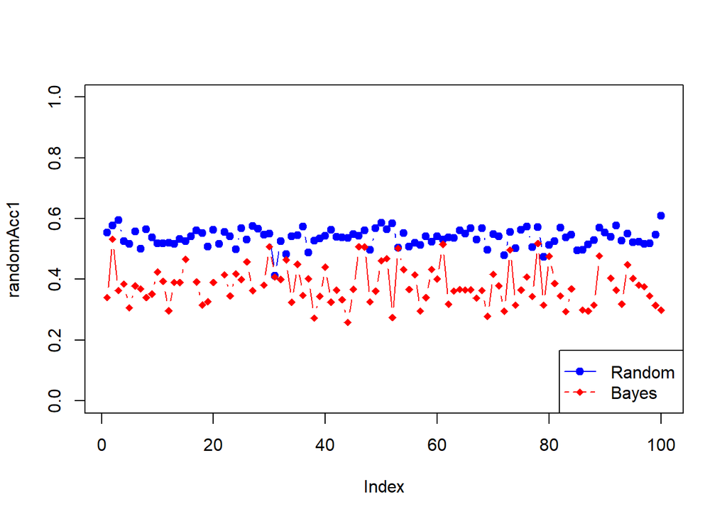

```r
plot(randomAcc1, type="b",ylim=c(0,1),col="blue",pch=19)
lines(bayesAcc1,type="b",col="red",pch=18)


legend("bottomright",legend=c("Random","Bayes"),col=c("blue","red"),pch=c(19,18),lty=1:2)
```

```r
ttest = t.test(randomAcc1, bayesAcc1)
print(ttest)
```

```
##
##  Welch Two Sample t-test
##
## data:  randomAcc1 and bayesAcc1
## t = 21.871, df = 130.87, p-value < 2.2e-16
## alternative hypothesis: true difference in means is not equal to 0
## 95 percent confidence interval:
##  0.1432454 0.1717354
## sample estimates:
## mean of x mean of y
## 0.5372520 0.3797616
```

```r
print(mean(bayesAcc1))
```

```
## [1] NaN
```

```r
print(mean(randomAcc1))
```

```
## [1] 0.537252
```

## **Model 3: Prediction model with smv + incentive + idle_men**

```r
bayesAcc2= c();
randomAcc2 = c();
```

```r
for(i in 1:100){
  ind = sample(2, nrow(dat),replace = T, prob = c(0.75,0.25))
  table(ind)
  train_data = dat[ind == 1, ]
  test_data = dat[ind == 2, ]
  print(dim(train_data))
  print(dim(test_data))

  # Naive Bayes  model using train data
  dat_bayes = naiveBayes(train_data$achieved ~  smv + incentive + idle_men, data = train_data)
  print("Results of Naive Bayes classifier")
  # Evaluate the model using test data
  testPrediction = predict(dat_bayes, test_data)
  conf = table(test_data$achieved , testPrediction)
  cm = confusionMatrix(test_data$achieved , testPrediction)
  bayesAcc2[i] = mean(cm$byClass[])
  print(bayesAcc2[i])

  # Random Forest model using the train data
  dat_random = randomForest(train_data$achieved  ~ smv + incentive + idle_men, data = train_data)
  # Evaluate the model using test data
  testPrediction = predict(dat_random, test_data)
  conf = table(test_data$achieved , testPrediction)
  cm = confusionMatrix(test_data$achieved , testPrediction)
  print("Results of Random Forest  classifier")
  randomAcc2[i] = mean(cm$byClass[])
  print(randomAcc2[i])
}
```

```
## [1] 900  11
## [1] 297  11
## [1] "Results of Naive Bayes classifier"
## [1] 0.3910687
## [1] "Results of Random Forest  classifier"
## [1] 0.4987006
## [1] 924  11
## [1] 273  11
## [1] "Results of Naive Bayes classifier"
## [1] 0.294857
## [1] "Results of Random Forest  classifier"
## [1] 0.4859171
## [1] 936  11
## [1] 261  11
## [1] "Results of Naive Bayes classifier"
```

[output cut: 585 more lines]

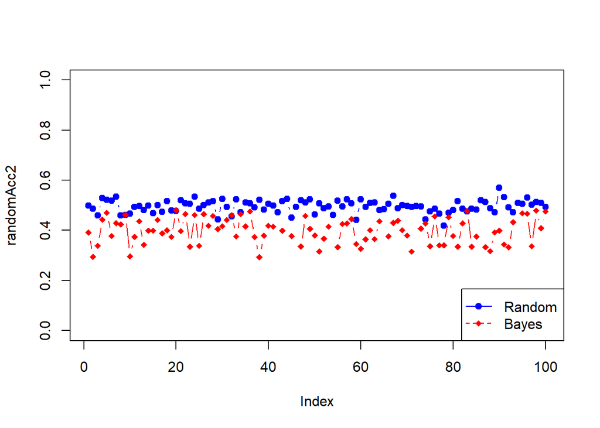

```r
plot(randomAcc2, type="b",ylim=c(0,1),col="blue",pch=19)
lines(bayesAcc2,type="b",col="red",pch=18)


legend("bottomright",legend=c("Random","Bayes"),col=c("blue","red"),pch=c(19,18),lty=1:2)
```

```r
ttest = t.test(randomAcc2, bayesAcc2)
print(ttest)
```

```
##
##  Welch Two Sample t-test
##
## data:  randomAcc2 and bayesAcc2
## t = 16.856, df = 129.99, p-value < 2.2e-16
## alternative hypothesis: true difference in means is not equal to 0
## 95 percent confidence interval:
##  0.0866767 0.1097293
## sample estimates:
## mean of x mean of y
## 0.4958177 0.3976147
```

```r
print(mean(bayesAcc2))
```

```
## [1] NaN
```

```r
print(mean(randomAcc2))
```

```
## [1] 0.4958177
```